# Examiners Benchmarking Research For Minnesota Banking Department

CSBS Analytics and Research

Jan 31, 2017

# Overview

The purpose of this study is to find a correlation between the number of examiners and some key characteristics of the bank that are regulated in the state.

# Data Description

## Data Overview

We consolidated the profile data and Statistics on Depository Institutions (SDI) as of Q4 of each year.

*Source:*

1. FDIC website. https://www5.fdic.gov/sdi/main.asp?formname=customddownload
2. Profile Data.

## Relevant variables:

- Number of examiners by state (Profile)

*Independent variable*:

- Aggregate assets under supervision by the department (SDI)
- Number of state chartered banks by state (SDI)

# Methodology

## Assumptions:

1. There is a linear relationship between the independent variables and dependent variables.
2. The independent variables are not random. There is no exact linear relationship between any independent variables.
3. The locations of the banks will not have a significant impact on the time of examining work.
4. All the states follow similar examining process.
5. The CAMELS rating of previous year doesn’t have a significant impact on the time of examination for the current year.
6. Bank examiners of all the states meet the similar productivity standards.
7. The diversity of the bank assets is already considered in bank size, thus will not have a significant impact on the time of examining work.

**Model:** Multi-variate Model.

The multi-variate linear regression model is defined as

$$y_{i} = \alpha + \beta_{i}x_{i} + \epsilon_{i}$$

in which $\epsilon_i$ is the error or residual associated with observation *i*.

Data for District of Columbia and Iowa are missing in 2015 and replaced with data from 2014.

We drew the data distribution in R. After removing the outlier New York, we can see a linear relationship.

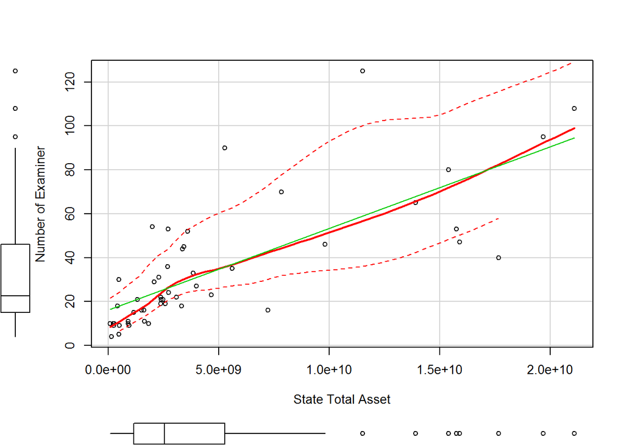

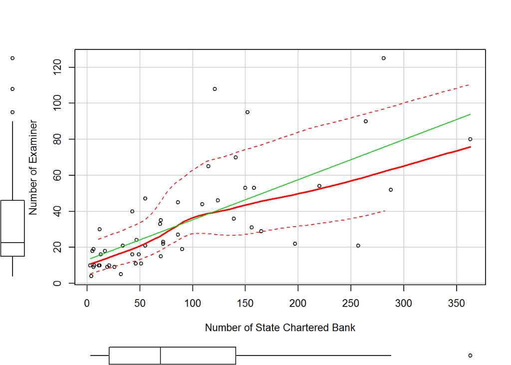

**Model from R**

```
Call:
lm(formula = N_INT2_EXAMINER ~ SDI_TOTAL_ASSET + N_SDI_BANK,
    data = rdb)

Residuals:
   Min     1Q Median     3Q    Max
-31.36  -7.19  -0.99   4.67  43.44

Coefficients:
                Estimate Std. Error t value Pr(>|t|)
(Intercept)     6.24e+00   3.03e+00    2.06    0.045 *
SDI_TOTAL_ASSET 2.80e-09   3.84e-10    7.29  2.9e-09 ***
N_SDI_BANK      1.53e-01   2.46e-02    6.24  1.2e-07 ***
---
Signif. codes:  0 '***' 0.001 '**' 0.01 '*' 0.05 '.' 0.1 ' ' 1

Residual standard error: 13.9 on 47 degrees of freedom
Multiple R-squared:  0.76,  Adjusted R-squared:  0.75
F-statistic: 74.6 on 2 and 47 DF,  p-value: 2.6e-15
```

The number of asterisks represents the degree of significance where *** indicates strong correlation and * indicates weak correlation. Both variables are significant in our model. **Bank Total Asset** (*SDI_TOTAL_ASSET*) is the most significant one. The R-square shows the percentage of the data that are captured in the trend. According to the result shown above, 76.047% of the data are explained in this model.

In consequence, the Number of Examiner for a State Department can be approximated with the following linear equation:

$$Number\ of\ Examiner = 2.799\times 10^{-9} * Total\ Asset + 0.153*Number\ of\ Bank + 6.238$$

The equation shows that the coefficient for total assets is $2.799\times 10^{-9}$ It indicates that, other variables remaining the same, for each 1 billion assets increase, there should be about 3 more examiners. The coefficient for number of banks is 0.153. It indicates that, other variables remaining the same, for each increase of 100 banks, there should be 15 more examiners.

Minnesota had 257 banks, $2,393,685,847 total bank assets and 21 examiners as of Dec 31<sup>st</sup>. After we input these numbers in the formula, we get the number 52. Therefore, the estimated benchmark from Minnesota in 2015 is 52.

# Conclusion

In general, the study found that Minnesota appeared to be understaffed by 31 examiners in 2015.

For future improvement, we will consider risk and geographical factors.

# Appendix

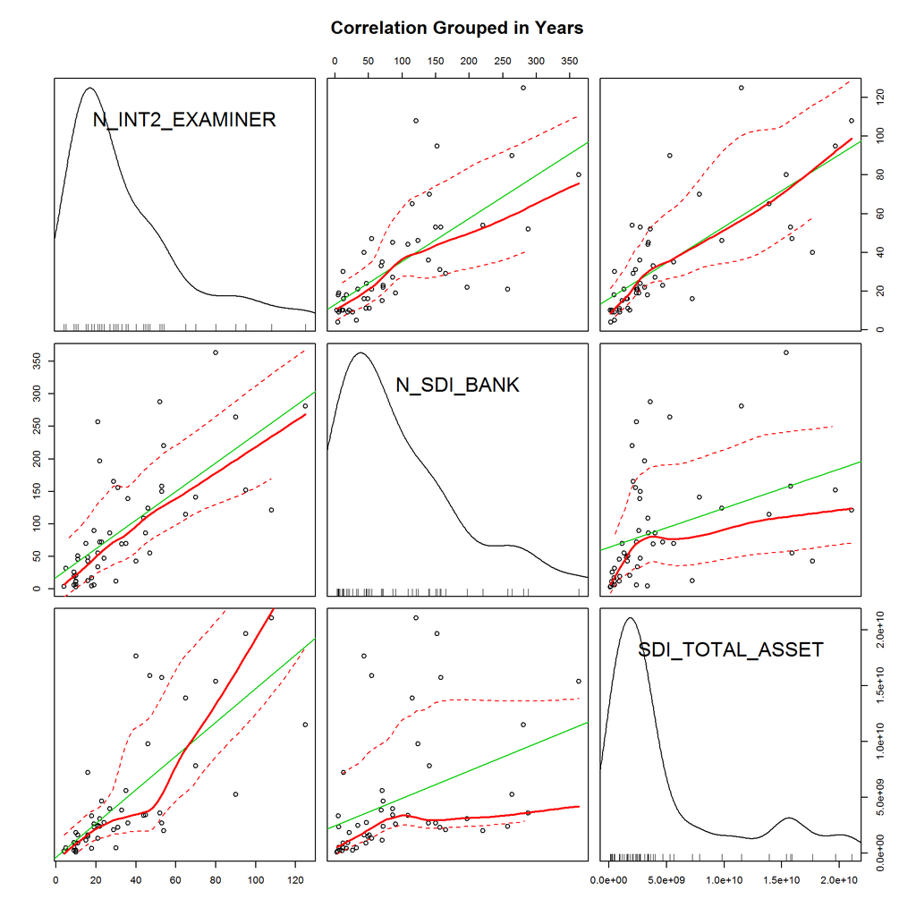

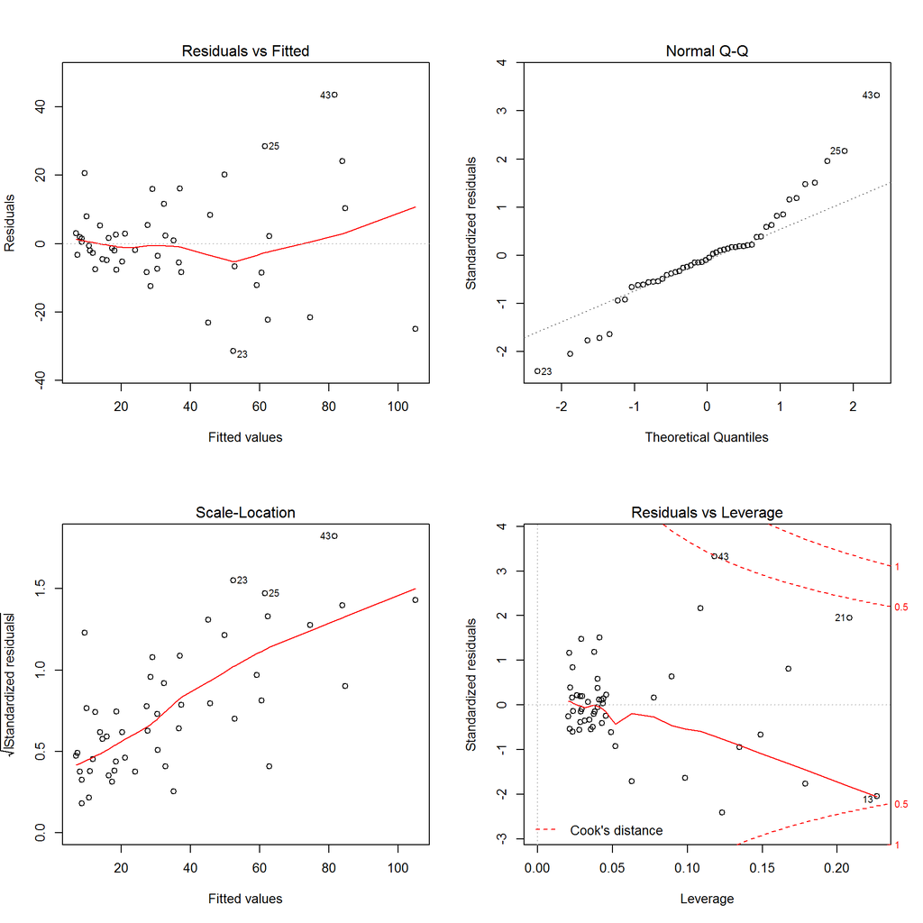